# EEG project

```r
# load data
demo <- read.delim("HypothermiaFinalDemographics.Blinded.txt", header = TRUE, as.is = TRUE, na.strings = c("NA", "X"))
```

## 1. Basic data measures

```r
# create a data set contains demographic measures of the patients.
basic=demo[,1:13]
# first, convert all data to factor levels or numeric data, so that can do summary. Also, convert all words to uppercase.
basic$First.Post.Arrest.LA=as.numeric(basic$First.Post.Arrest.LA)
basic=data.frame(lapply(basic, function(v) {
  if (is.character(v)) return(toupper(v))
  else return(v)
}))
# I haven't figure out a way to combine the two kind of "IN"s into one.
basic$Identifier=as.character(basic$Identifier)
basic$Date.of.Arrest=as.character(basic$Date.of.Arrest)
summary(basic)
```

```
##   Identifier             Age       Gender Date.of.Arrest     Arrest.Rhythm
##  Length:66          Min.   :19.0   F:29   Length:66          ASY  : 6
##  Class :character   1st Qu.:49.0   M:37   Class :character   PEA  :27
##  Mode  :character   Median :55.5          Mode  :character   VFIB :27
##                     Mean   :58.1                             VT   : 1
##                     3rd Qu.:67.5                             VTACH: 5
##                     Max.   :93.0
##
##  Binary.Rhythm      ROSC      Multiple.Arrests             Site.of.Arrest
##  NS:35         Min.   : 1.0   NO :56           ED                 : 5
##  S :31         1st Qu.: 6.0   YES:10           FIELD              :36
##                Median :15.0                    FIELD/TRANSFER     : 7
##                Mean   :17.8                    HOSPITAL           : 1
##                3rd Qu.:20.0                    IN                 :15
##                Max.   :75.0                    IN                 : 1
##                NA's   :25                      IN/TRANSFER        : 1
##       Cooling.Method First.Post.Arrest.Temp First.Post.Arrest.pH
##  COOL LINE   :17     Min.   :32.6           Min.   :6.80
##  NO COOL LINE:49     1st Qu.:34.7           1st Qu.:7.03
##                      Median :35.7           Median :7.21
##                      Mean   :35.7           Mean   :7.18
##                      3rd Qu.:36.7           3rd Qu.:7.32
##                      Max.   :38.0           Max.   :7.57
##
##  First.Post.Arrest.LA
##  Min.   : 1.00
##  1st Qu.: 4.50
##  Median : 7.85
##  Mean   : 7.73
##  3rd Qu.:10.25
##  Max.   :17.10
##  NA's   :4
```

```r
#basic$Multiple.Arrests=tolower(basic$Multiple.Arrests)
#basic$Gender=as.factor(basic$Gender)
#basic$Arrest.Rhythm=as.factor(basic$Arrest.Rhythm)
#basic$Binary.Rhythm=as.factor(basic$Binary.Rhythm)
#basic$Multiple.Arrests=as.factor(basic$Multiple.Arrests)
#basic$Site.of.Arrest=as.factor(basic$Site.of.Arrest)
#basic$Cooling.Method=as.factor(basic$Cooling.Method)
```

Since ROSC contains 25 NAs, I think it would be appropriate to eliminate this variable.

Categories of Site of Arrest may need combined to eliminate HOSPITAL, and IN/TRANSFER, which only have one observation.

```r
# Use which(is.na(x)) to identify case number of NAs in First.Post.Arres.LA, and find out corresponding identifiers.
which(is.na(basic$First.Post.Arrest.LA))
```

```
## [1] 30 38 45 48
```

```r
basic$Identifier[which(is.na(basic$First.Post.Arrest.LA))]
```

```
## [1] "CA0036" "CA0045" "CA0052" "CA0055"
```

## 2. Time temperature data

```r
temps <- read.delim("TempCurveFinal.txt", header = FALSE, as.is = TRUE)
temps[seq(2, nrow(temps), by = 2), 1] <- temps[seq(1, nrow(temps) - 1, by = 2),1]
n <- (nrow(temps)/2)
## Plot and Re-Format loop:
#pdf("TempTimeCourse.pdf", height = 11, width = 8.5)
#par(mfrow = c(4, 1))
sampids <- temps[temps[, 2] == "Time", 1]
timecourse <- vector(mode = "list", length = n)
names(timecourse) <- sampids
for (i in 1:n) {
times <- temps[(2 * (i - 1) + 1), 3:ncol(temps)]
times <- times[times != ""]
hrs <- as.numeric(substr(times, 1, nchar(times) - 3))
mins <- as.numeric(substr(times, (nchar(times) - 1), nchar(times)))
times <- as.numeric(hrs + (mins/60))
temp <- temps[(2 * (i - 1) + 2), 3:ncol(temps)]
temp <- as.numeric(temp[temp != ""])
## Corrections will be applied to ✬temp✬ and ✬time✬ columns; the original,
timecourse[[i]] <- data.frame(time = times, temp = temp, orig.time = times,orig.temp = temp, nurse.error = rep(0, length(temp)))
rm(times, hrs, mins, temp)
}
```

```r
## Corrections (1) CA0006: the high point at around 30 hours is a nursing
## error.
timecourse[["CA0006"]]$temp[33] <- NA
timecourse[["CA0006"]]$nurse.error[33] <- 1
## (2) ***Time error: correct value obvious
timecourse[["CA0008"]]$time[24] <- 12.7833333
## (3) CA0012: Likewise, the low point just at the start was an error in
## nurse recording.
timecourse[["CA0012"]]$temp[2] <- NA
timecourse[["CA0012"]]$nurse.error[2] <- 1
## (4) CA0015: the two low points are consistently recorded by the
## nurses--while difficult to explain physiologically, it✬s hard to reconcile
## the points. NOTE: there are 5 points here w/in a period of about 12 min
timecourse[["CA0015"]]$temp[12:16] <- NA
timecourse[["CA0015"]]$nurse.error[12:16] <- 1
## (5) CA0018: the point at 36 degrees that is shifted is my error in
## transcribing the time. The actual time value is point 31:13
timecourse[["CA0018"]]$time[61] <- (31 + (13/60))
## (6) CA0028: The two outliers at the cooling plateau are nursing values,
## and are likely nursing error.
timecourse[["CA0028"]]$temp[42:44] <- NA
timecourse[["CA0028"]]$nurse.error[42:44] <- 1
## (7) CA0029: Nursing error.
timecourse[["CA0029"]]$temp[24] <- NA
timecourse[["CA0029"]]$nurse.error[24] <- 1
## (8) CA0031: apparently actual values--fever fluctuated rapidly. (9)
## CA0032: nursing error.
timecourse[["CA0032"]]$temp[27] <- NA
timecourse[["CA0032"]]$nurse.error[27] <- 1
## (10) CA0033: Overshot cooling--This appears real. (11) CA0035: Nursing
## errors
timecourse[["CA0035"]]$temp[41:43] <- NA
timecourse[["CA0035"]]$nurse.error[41:43] <- 1
## (12) CA0040: nursing error.
timecourse[["CA0040"]]$temp[44:47] <- NA
timecourse[["CA0040"]]$nurse.error[44:47] <- 1
## (13) CA0042: Nursing error
timecourse[["CA0042"]]$temp[22] <- NA
timecourse[["CA0042"]]$nurse.error[22] <- 1
## (14) CA0044: actual logged value. I can✬t completely discount it. (15)
## CA0045: Arrives at cold temperature--fluctuant temperatures -- actual
## values. I can believethis one. (16) CA0046: my error. The last point
## should read 35.6 temperature
timecourse[["CA0046"]]$temp[95] <- 35.6
## (17) CA0056: the one really discordant value at cooling plateau was a
## nursing value--looks like it✬s in error
timecourse[["CA0056"]]$temp[32] <- NA
timecourse[["CA0056"]]$nurse.error[32] <- 1
4## (18) CA0058: Clearly my error! 31:04
```

```
## [1] 4
```

```r
timecourse[["CA0058"]]$time[23] <- (31 + (4/60))
## (19) CA0060: The temperature that is off is 33.1 not 3.1; my error.
timecourse[["CA0060"]]$temp[24] <- 33.1
## (20) *** CA0060: the 23rd time, recorded as 27.483, is out of sync; very
## likely = 21.483. Corrected as such.
timecourse[["CA0060"]]$time[23] <- 21.48333333
## (21) CA0061: My error--33.4
timecourse[["CA0061"]]$temp[87] <- 33.4
## (22) *** CA0061: Out of sync time = 36.26667 is evidently 26.26667
## corrected as such
timecourse[["CA0061"]]$time[53] <- 26.26667
## (23) *** CA0061: Out of sync time = 44.13333 is evidently 52.13333
## corrected as such
timecourse[["CA0061"]]$time[147] <- 52.13333
## (24) CA0065: Actual values--Probably a nursing error.
timecourse[["CA0065"]]$temp[15:17] <- NA
timecourse[["CA0065"]]$nurse.error[15:17] <- 1
## (25) CA0067: The initial blip is temp = 32.6, the second, much smaller
## blip is an actual value.
timecourse[["CA0067"]]$temp[73] <- 32.6
## (26) *** CA0067: Out of sync time value 27.83; very likely = 17.83
## corrected as such.
timecourse[["CA0067"]]$time[47] <- 17.8333333
## (27) CA0068: My error, the value is 34.6
timecourse[["CA0068"]]$temp[28] <- 34.6
## (28) CA0070: these are the right values -- I think they are overcorrection
## of a fever and are physiologic
```

### 2.1 Unusual observation patterns

For time temperature data, there are some cases need further examination.

#### 2.1.1. Obserevation without post cooling period.

Patient CA0003 is of this type. He doesn’t have the temperature after cooling period. We cannot find out if the patient had fever or not, not to mention the duration and intensity of fever.

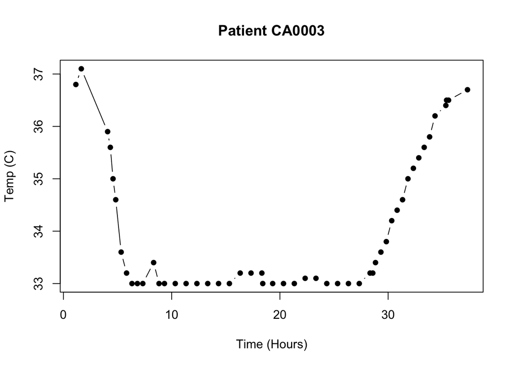

```r
plot(timecourse[[1]]$time, timecourse[[1]]$temp, type = "b", pch = 16, xlab = "Time (Hours)",ylab = "Temp (C)", main = paste("Patient ", sampids[1], sep = ""))
```

#### 2.1.2. Observation contains uninterpretable information.

First temperature of patient CA0007 is close to the cooling period temperature of other observations. It’s hard to know what is going on with this patient, since there is no normal temperature, and no post cooling period temperature.

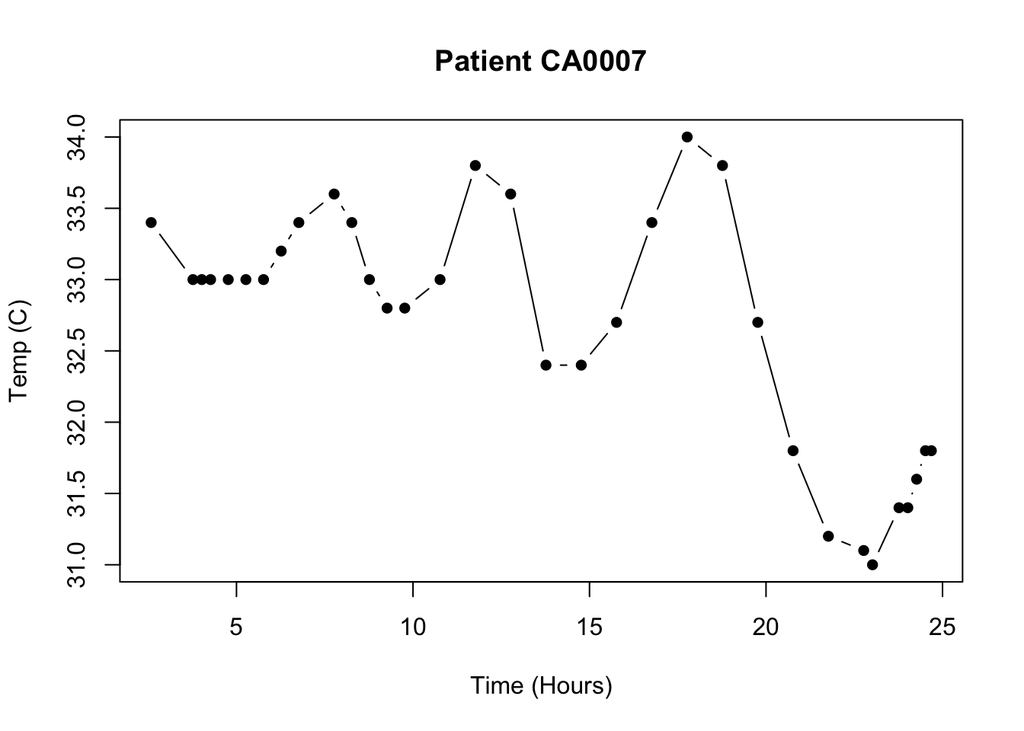

```r
plot(timecourse[[5]]$time, timecourse[[5]]$temp, type = "b", pch = 16, xlab = "Time (Hours)",ylab = "Temp (C)", main = paste("Patient ", sampids[5], sep = ""))
```

#### 2.1.3. Fluctuation in cooling period.

Patients’ temepature during cooling period are usually very stable. However, Patient CA0023 ’s temperature shows fluctuation during cooling period. Some other observations show the same pattern, but not as volatile.

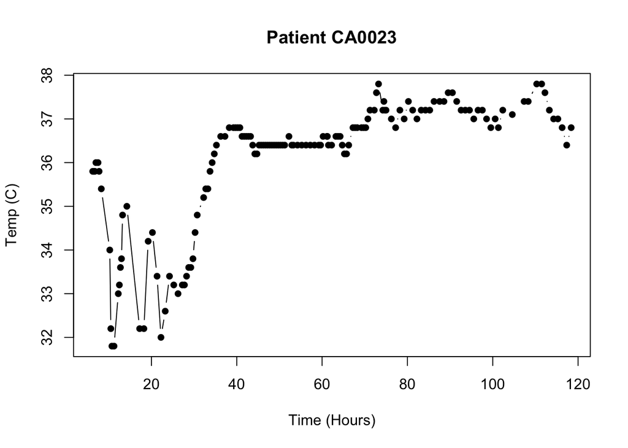

```r
plot(timecourse[[18]]$time, timecourse[[18]]$temp, type = "b", pch = 16, xlab = "Time (Hours)",ylab = "Temp (C)", main = paste("Patient ", sampids[18], sep = ""))
```

#### 2.1.4. Lack of Pre-cooling period.

This patient doesn’t have pre-cooling temeparature. May lack some baseline measure of body temperature.

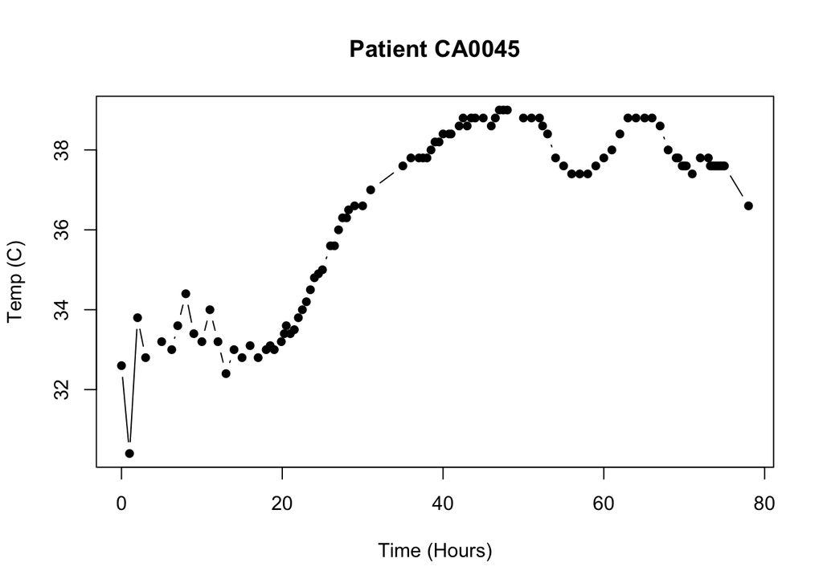

```r
plot(timecourse[[38]]$time, timecourse[[38]]$temp, type = "b", pch = 16, xlab = "Time (Hours)",ylab = "Temp (C)", main = paste("Patient ", sampids[38], sep = ""))
```

### 2.2 Summarizing Time-Temperature Data

I would suggest calculating the following statistics for each patient, and decide which observation to eliminate accordingly:

1. whether or not the patient had a fever after treatment
2. the duration of fever,
3. the intensity of fever,
4. the patient’s baseline temperature before cooling
5. minimum temperature
6. new baseline temperature after warming.

## 3.EEG data

Every patient have recorded at least one day of EEG, so first data of EEG data is definitely included.

## 4. Multicollinearity

Testing for multicollinearity among variables require to first fit a regression. Without response variable, we cannot test it.

We cannot do a correlation matrix since many variables are unordered categorical.